# Course-End Project: Employee Turnover Analytics

## Project Statement:

Portobello Tech is an app innovator that has devised an intelligent way of predicting employee turnover within the company. It periodically evaluates employees' work details including the number of projects they worked upon, average monthly working hours, time spent in the company, promotions in the last 5 years, and salary level. Data from prior evaluations show the employee’s satisfaction at the workplace. The data could be used to identify patterns in work style and their interest to continue to work in the company. The HR Department owns the data and uses it to predict employee turnover. Employee turnover refers to the total number of workers who leave a company over a certain time period. As the ML Developer assigned to the HR Department, you have been asked to create ML Programs to

- 1. Perform data quality check by checking for missing values if any.
- 1. Understand what factors contributed most to employee turnover by EDA.
- 1. Perform clustering of Employees who left based on their satisfaction and evaluation.
- 1. Handle the left Class Imbalance using SMOTE technique.
- 1. Perform k-fold cross-validation model training and evaluate performance.
- 1. Identify the best model and justify the evaluation metrics used.
- 1. Suggest various retention strategies for targeted employees.

# Perform the following steps:

## 1. Perform data quality check by checking for missing values if any.

## 2. Understand what factors contributed most to employee turnover by EDA.

### 2.1. Draw a heatmap of the Correlation Matrix between all numerical features/columns in the data.

### 2.2. Draw the distribution plot of

- Employee Satisfaction (use column satisfaction_level)
- Employee Evaluation (use column last_evaluation)
- Employee Average Monthly Hours (use column average_montly_hours) ### 2.3. Draw the bar plot of Employee Project Count of both employees who left and who stayed in the organization (use column number_project and hue column left) and give your inferences from the plot. ## 3. Perform clustering of Employees who left based on their satisfaction and evaluation. ### 3.1. Choose columns satisfaction_level, last_evaluation and left. ### 3.2. Do KMeans clustering of employees who left the company into 3 clusters. ### 3.3. Based on the satisfaction and evaluation factors, give your thoughts on the employee clusters. ## 4. Handle the left Class Imbalance using SMOTE technique. ### 4.1. Pre-Process the data by converting categorical columns to numerical columns by
- Separating categorical variables and numeric variables.
- Applying get_dummies() to the categorical variables.
- Combining categorical variables and numeric variables. ### 4.2. Do the stratified split of the dataset to train and test in the ratio 80:20 with random_state=123. ### 4.3. Upsample the train dataset using SMOTE technique from the imblearn module. ## 5. Perform 5-Fold cross-validation model training and evaluate performance. ### 5.1. Train a Logistic Regression model and apply a 5-Fold CV and plot the classification report. ### 5.2. Train a Random Forest Classifier model and apply the 5-Fold CV and plot the classification report. ### 5.3. Train a Gradient Boosting Classifier model and apply the 5-Fold CV and plot the classification report. ## 6. Identify the best model and justify the evaluation metrics used. ### 6.1. Find the ROC/AUC for each model and plot the ROC curve. ### 6.2. Find the confusion matrix for each of the models. ### 6.3. From the confusion matrix, explain which metric needs to be used- Recall or Precision? ## 7. Suggest various retention strategies for targeted employees. ### 7.1. Using the best model, predict the probability of employee turnover in the test data. ### 7.2. Based on the below probability score range, categorize the employees into four zones and suggest your thoughts on the retention strategies for each zone.
- Safe Zone (Green) (Score < 20%)
- Low Risk Zone (Yellow) (20% < Score < 60%)
- Medium Risk Zone (Orange) (60% < Score < 90%)
- High Risk Zone (Red) (Score > 90%).

```python
import numpy as np
import pandas as pd
import matplotlib.pyplot as plt
import seaborn as sns

import warnings
warnings.filterwarnings('ignore')
```

```python
from sklearn.model_selection import StratifiedShuffleSplit
from imblearn.over_sampling import SMOTE
from sklearn.linear_model import LogisticRegression
from sklearn.ensemble import RandomForestClassifier, GradientBoostingClassifier
from sklearn.model_selection import cross_val_score, cross_val_predict
from sklearn.metrics import classification_report, confusion_matrix, ConfusionMatrixDisplay
```

```python
df = pd.read_excel('Employee Turnover Dataset.xlsx')
```

```python
df.head()
```

|  | satisfaction_level | last_evaluation | number_project | average_montly_hours | time_spend_company | Work_accident | left | promotion_last_5years | sales | salary |
| --- | --- | --- | --- | --- | --- | --- | --- | --- | --- | --- |
| 0 | 0.38 | 0.53 | 2 | 157 | 3 | 0 | 1 | 0 | sales | low |
| 1 | 0.80 | 0.86 | 5 | 262 | 6 | 0 | 1 | 0 | sales | medium |
| 2 | 0.11 | 0.88 | 7 | 272 | 4 | 0 | 1 | 0 | sales | medium |
| 3 | 0.72 | 0.87 | 5 | 223 | 5 | 0 | 1 | 0 | sales | low |
| 4 | 0.37 | 0.52 | 2 | 159 | 3 | 0 | 1 | 0 | sales | low |

```python
df.tail()
```

|  | satisfaction_level | last_evaluation | number_project | average_montly_hours | time_spend_company | Work_accident | left | promotion_last_5years | sales | salary |
| --- | --- | --- | --- | --- | --- | --- | --- | --- | --- | --- |
| 14994 | 0.40 | 0.57 | 2 | 151 | 3 | 0 | 1 | 0 | support | low |
| 14995 | 0.37 | 0.48 | 2 | 160 | 3 | 0 | 1 | 0 | support | low |
| 14996 | 0.37 | 0.53 | 2 | 143 | 3 | 0 | 1 | 0 | support | low |
| 14997 | 0.11 | 0.96 | 6 | 280 | 4 | 0 | 1 | 0 | support | low |
| 14998 | 0.37 | 0.52 | 2 | 158 | 3 | 0 | 1 | 0 | support | low |

```python
df.shape
```

```
(14999, 10)
```

### 1. Perform data quality check by checking for missing values if any.

```python
df.isna().sum()
```

```
satisfaction_level       0
last_evaluation          0
number_project           0
average_montly_hours     0
time_spend_company       0
Work_accident            0
left                     0
promotion_last_5years    0
sales                    0
salary                   0
dtype: int64
```

```python
df.describe().T
```

|  | count | mean | std | min | 25% | 50% | 75% | max |
| --- | --- | --- | --- | --- | --- | --- | --- | --- |
| satisfaction_level | 14999.0 | 0.612834 | 0.248631 | 0.09 | 0.44 | 0.64 | 0.82 | 1.0 |
| last_evaluation | 14999.0 | 0.716102 | 0.171169 | 0.36 | 0.56 | 0.72 | 0.87 | 1.0 |
| number_project | 14999.0 | 3.803054 | 1.232592 | 2.00 | 3.00 | 4.00 | 5.00 | 7.0 |
| average_montly_hours | 14999.0 | 201.050337 | 49.943099 | 96.00 | 156.00 | 200.00 | 245.00 | 310.0 |
| time_spend_company | 14999.0 | 3.498233 | 1.460136 | 2.00 | 3.00 | 3.00 | 4.00 | 10.0 |
| Work_accident | 14999.0 | 0.144610 | 0.351719 | 0.00 | 0.00 | 0.00 | 0.00 | 1.0 |
| left | 14999.0 | 0.238083 | 0.425924 | 0.00 | 0.00 | 0.00 | 0.00 | 1.0 |
| promotion_last_5years | 14999.0 | 0.021268 | 0.144281 | 0.00 | 0.00 | 0.00 | 0.00 | 1.0 |

```python
df['sales'].value_counts()
```

```
sales          4140
technical      2720
support        2229
IT             1227
product_mng     902
marketing       858
RandD           787
accounting      767
hr              739
management      630
Name: sales, dtype: int64
```

```python
df.rename(columns={'sales':'department'},inplace=True)
```

```python
df.columns
```

```
Index(['satisfaction_level', 'last_evaluation', 'number_project',
       'average_montly_hours', 'time_spend_company', 'Work_accident', 'left',
       'promotion_last_5years', 'department', 'salary'],
      dtype='object')
```

```python
df['salary'].value_counts()
```

```
low       7316
medium    6446
high      1237
Name: salary, dtype: int64
```

## 2. Understand what factors contributed most to employee turnover by EDA.

### 2.1. Draw a heatmap of the Correlation Matrix between all numerical features/columns in the data.

```python
corr = df.corr()
corr
```

|  | satisfaction_level | last_evaluation | number_project | average_montly_hours | time_spend_company | Work_accident | left | promotion_last_5years |
| --- | --- | --- | --- | --- | --- | --- | --- | --- |
| satisfaction_level | 1.000000 | 0.105021 | -0.142970 | -0.020048 | -0.100866 | 0.058697 | -0.388375 | 0.025605 |
| last_evaluation | 0.105021 | 1.000000 | 0.349333 | 0.339742 | 0.131591 | -0.007104 | 0.006567 | -0.008684 |
| number_project | -0.142970 | 0.349333 | 1.000000 | 0.417211 | 0.196786 | -0.004741 | 0.023787 | -0.006064 |
| average_montly_hours | -0.020048 | 0.339742 | 0.417211 | 1.000000 | 0.127755 | -0.010143 | 0.071287 | -0.003544 |
| time_spend_company | -0.100866 | 0.131591 | 0.196786 | 0.127755 | 1.000000 | 0.002120 | 0.144822 | 0.067433 |
| Work_accident | 0.058697 | -0.007104 | -0.004741 | -0.010143 | 0.002120 | 1.000000 | -0.154622 | 0.039245 |
| left | -0.388375 | 0.006567 | 0.023787 | 0.071287 | 0.144822 | -0.154622 | 1.000000 | -0.061788 |
| promotion_last_5years | 0.025605 | -0.008684 | -0.006064 | -0.003544 | 0.067433 | 0.039245 | -0.061788 | 1.000000 |

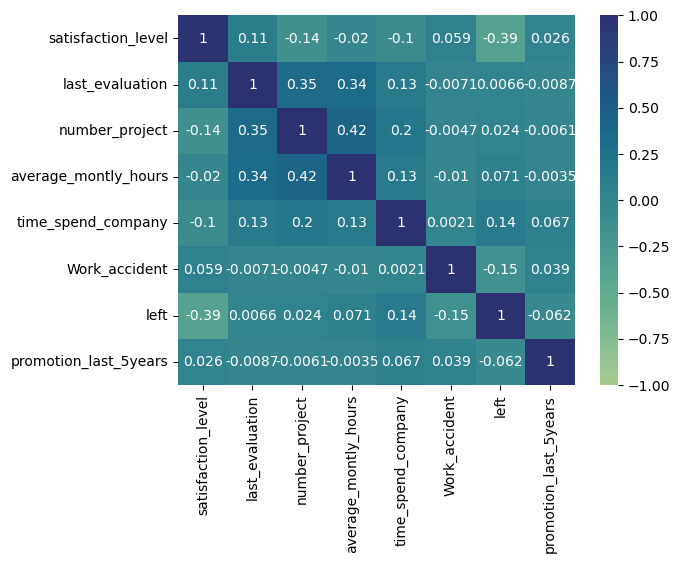

```python
sns.heatmap(corr, annot=True, vmin=-1,vmax=+1,cmap="crest")
```

### 2.2. Draw the distribution plot of

- Employee Satisfaction (use column satisfaction_level)
- Employee Evaluation (use column last_evaluation)
- Employee Average Monthly Hours (use column average_montly_hours)

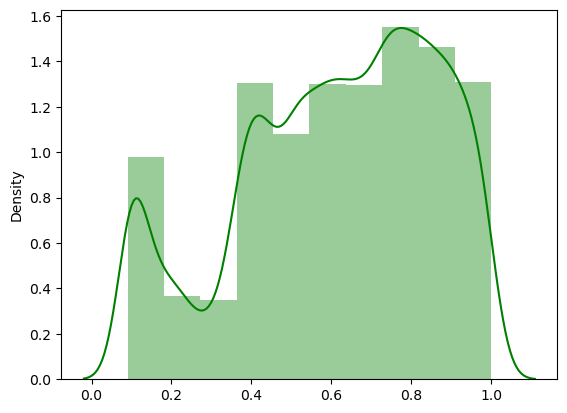

```python
sns.distplot(x=df['satisfaction_level'], hist=True,bins=10 ,color='green')
```

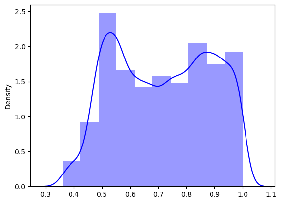

```python
sns.distplot(x=df['last_evaluation'], hist=True,bins=10 ,color='blue')
```

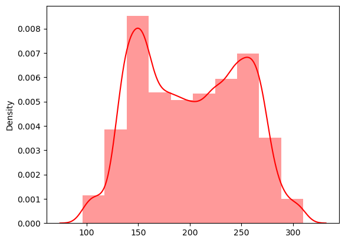

```python
sns.distplot(x=df['average_montly_hours'], hist=True,bins=10 ,color='red')
```

### 2.3. Draw the bar plot of Employee Project Count of both employees who left and who stayed in the organization (use column number_project and hue column left) and give your inferences from the plot.

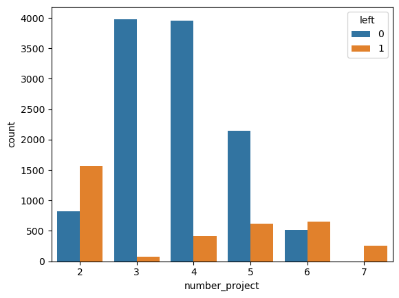

```python
sns.countplot(data=df, x='number_project', hue='left')
```

## 3. Perform clustering of Employees who left based on their satisfaction and evaluation.

### 3.1. Choose columns satisfaction_level, last_evaluation and left.

```python
cluster = df[['satisfaction_level', 'last_evaluation', 'left']].copy()
cluster.head()
```

|  | satisfaction_level | last_evaluation | left |
| --- | --- | --- | --- |
| 0 | 0.38 | 0.53 | 1 |
| 1 | 0.80 | 0.86 | 1 |
| 2 | 0.11 | 0.88 | 1 |
| 3 | 0.72 | 0.87 | 1 |
| 4 | 0.37 | 0.52 | 1 |

```python
cluster['left'].value_counts()
```

```
0    11428
1     3571
Name: left, dtype: int64
```

```python
cluster.shape
```

```
(14999, 3)
```

```python
from sklearn.cluster import KMeans
```

```python
kmc = KMeans(n_clusters=3, random_state=42)
```

```python
y_predicted = kmc.fit_predict(cluster)
y_predicted
```

```
array([1, 1, 1, ..., 1, 1, 1])
```

```python
cluster['cluster']=y_predicted
cluster.sample(5)
```

|  | satisfaction_level | last_evaluation | left | cluster |
| --- | --- | --- | --- | --- |
| 12175 | 0.54 | 0.74 | 1 | 1 |
| 12350 | 0.09 | 0.80 | 1 | 1 |
| 6244 | 0.54 | 0.93 | 0 | 2 |
| 2901 | 0.50 | 0.70 | 0 | 2 |
| 264 | 0.42 | 0.50 | 1 | 1 |

```python
kmc.cluster_centers_
```

```
array([[8.13757657e-01, 7.40231585e-01, 7.29971639e-15],
       [4.40098012e-01, 7.18112574e-01, 1.00000000e+00],
       [4.59096093e-01, 6.80477297e-01, 3.46944695e-15]])
```

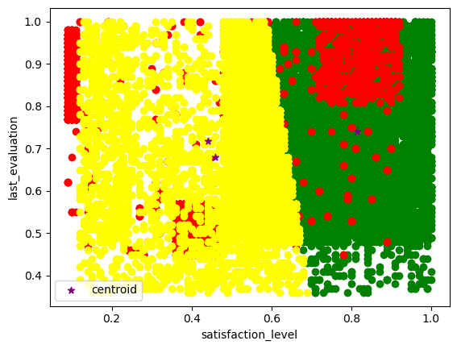

```python
cluster1 = cluster[cluster.cluster==0]
cluster2 = cluster[cluster.cluster==1]
cluster3 = cluster[cluster.cluster==2]
plt.scatter(cluster1['satisfaction_level'],cluster1['last_evaluation'],color='green')
plt.scatter(cluster2['satisfaction_level'],cluster2['last_evaluation'],color='red')
plt.scatter(cluster3['satisfaction_level'],cluster3['last_evaluation'],color='yellow')
plt.scatter(kmc.cluster_centers_[:,0],kmc.cluster_centers_[:,1],color='purple',marker='*',label='centroid')
plt.xlabel('satisfaction_level')
plt.ylabel('last_evaluation')
plt.legend()
```

## 4. Handle the left Class Imbalance using SMOTE technique.

### 4.1. Pre-Process the data by converting categorical columns to numerical columns by

- Separating categorical variables and numeric variables.
- Applying get_dummies() to the categorical variables.
- Combining categorical variables and numeric variables.

```python
df.head()
```

|  | satisfaction_level | last_evaluation | number_project | average_montly_hours | time_spend_company | Work_accident | left | promotion_last_5years | department | salary |
| --- | --- | --- | --- | --- | --- | --- | --- | --- | --- | --- |
| 0 | 0.38 | 0.53 | 2 | 157 | 3 | 0 | 1 | 0 | sales | low |
| 1 | 0.80 | 0.86 | 5 | 262 | 6 | 0 | 1 | 0 | sales | medium |
| 2 | 0.11 | 0.88 | 7 | 272 | 4 | 0 | 1 | 0 | sales | medium |
| 3 | 0.72 | 0.87 | 5 | 223 | 5 | 0 | 1 | 0 | sales | low |
| 4 | 0.37 | 0.52 | 2 | 159 | 3 | 0 | 1 | 0 | sales | low |

```python
df.info()
```

```
<class 'pandas.core.frame.DataFrame'>
RangeIndex: 14999 entries, 0 to 14998
Data columns (total 10 columns):
 #   Column                 Non-Null Count  Dtype
---  ------                 --------------  -----
 0   satisfaction_level     14999 non-null  float64
 1   last_evaluation        14999 non-null  float64
 2   number_project         14999 non-null  int64
 3   average_montly_hours   14999 non-null  int64
 4   time_spend_company     14999 non-null  int64
 5   Work_accident          14999 non-null  int64
 6   left                   14999 non-null  int64
 7   promotion_last_5years  14999 non-null  int64
 8   department             14999 non-null  object
 9   salary                 14999 non-null  object
dtypes: float64(2), int64(6), object(2)
memory usage: 1.1+ MB
```

```python
df['department'].value_counts()
```

```
sales          4140
technical      2720
support        2229
IT             1227
product_mng     902
marketing       858
RandD           787
accounting      767
hr              739
management      630
Name: department, dtype: int64
```

```python
department = pd.get_dummies(df['department'], prefix='department', prefix_sep='_', drop_first=True)
department
```

|  | department_RandD | department_accounting | department_hr | department_management | department_marketing | department_product_mng | department_sales | department_support | department_technical |
| --- | --- | --- | --- | --- | --- | --- | --- | --- | --- |
| 0 | 0 | 0 | 0 | 0 | 0 | 0 | 1 | 0 | 0 |
| 1 | 0 | 0 | 0 | 0 | 0 | 0 | 1 | 0 | 0 |
| 2 | 0 | 0 | 0 | 0 | 0 | 0 | 1 | 0 | 0 |
| 3 | 0 | 0 | 0 | 0 | 0 | 0 | 1 | 0 | 0 |
| 4 | 0 | 0 | 0 | 0 | 0 | 0 | 1 | 0 | 0 |
| ... | ... | ... | ... | ... | ... | ... | ... | ... | ... |
| 14994 | 0 | 0 | 0 | 0 | 0 | 0 | 0 | 1 | 0 |
| 14995 | 0 | 0 | 0 | 0 | 0 | 0 | 0 | 1 | 0 |
| 14996 | 0 | 0 | 0 | 0 | 0 | 0 | 0 | 1 | 0 |
| 14997 | 0 | 0 | 0 | 0 | 0 | 0 | 0 | 1 | 0 |
| 14998 | 0 | 0 | 0 | 0 | 0 | 0 | 0 | 1 | 0 |

14999 rows × 9 columns

```python
df['salary'].value_counts()
```

```
low       7316
medium    6446
high      1237
Name: salary, dtype: int64
```

```python
salary =  pd.get_dummies(df['salary'], prefix='salary', prefix_sep='_', drop_first=True)
salary
```

|  | salary_low | salary_medium |
| --- | --- | --- |
| 0 | 1 | 0 |
| 1 | 0 | 1 |
| 2 | 0 | 1 |
| 3 | 1 | 0 |
| 4 | 1 | 0 |
| ... | ... | ... |
| 14994 | 1 | 0 |
| 14995 | 1 | 0 |
| 14996 | 1 | 0 |
| 14997 | 1 | 0 |
| 14998 | 1 | 0 |

14999 rows × 2 columns

```python
data = pd.concat([df,department,salary], axis=1)
data.head()
```

|  | satisfaction_level | last_evaluation | number_project | average_montly_hours | time_spend_company | Work_accident | left | promotion_last_5years | department | salary | ... | department_accounting | department_hr | department_management | department_marketing | department_product_mng | department_sales | department_support | department_technical | salary_low | salary_medium |
| --- | --- | --- | --- | --- | --- | --- | --- | --- | --- | --- | --- | --- | --- | --- | --- | --- | --- | --- | --- | --- | --- |
| 0 | 0.38 | 0.53 | 2 | 157 | 3 | 0 | 1 | 0 | sales | low | ... | 0 | 0 | 0 | 0 | 0 | 1 | 0 | 0 | 1 | 0 |
| 1 | 0.80 | 0.86 | 5 | 262 | 6 | 0 | 1 | 0 | sales | medium | ... | 0 | 0 | 0 | 0 | 0 | 1 | 0 | 0 | 0 | 1 |
| 2 | 0.11 | 0.88 | 7 | 272 | 4 | 0 | 1 | 0 | sales | medium | ... | 0 | 0 | 0 | 0 | 0 | 1 | 0 | 0 | 0 | 1 |
| 3 | 0.72 | 0.87 | 5 | 223 | 5 | 0 | 1 | 0 | sales | low | ... | 0 | 0 | 0 | 0 | 0 | 1 | 0 | 0 | 1 | 0 |
| 4 | 0.37 | 0.52 | 2 | 159 | 3 | 0 | 1 | 0 | sales | low | ... | 0 | 0 | 0 | 0 | 0 | 1 | 0 | 0 | 1 | 0 |

5 rows × 21 columns

```python
data = data.drop(['department','salary'],axis=1)
data.shape
```

```
(14999, 19)
```

```python
data.head()
```

|  | satisfaction_level | last_evaluation | number_project | average_montly_hours | time_spend_company | Work_accident | left | promotion_last_5years | department_RandD | department_accounting | department_hr | department_management | department_marketing | department_product_mng | department_sales | department_support | department_technical | salary_low | salary_medium |
| --- | --- | --- | --- | --- | --- | --- | --- | --- | --- | --- | --- | --- | --- | --- | --- | --- | --- | --- | --- |
| 0 | 0.38 | 0.53 | 2 | 157 | 3 | 0 | 1 | 0 | 0 | 0 | 0 | 0 | 0 | 0 | 1 | 0 | 0 | 1 | 0 |
| 1 | 0.80 | 0.86 | 5 | 262 | 6 | 0 | 1 | 0 | 0 | 0 | 0 | 0 | 0 | 0 | 1 | 0 | 0 | 0 | 1 |
| 2 | 0.11 | 0.88 | 7 | 272 | 4 | 0 | 1 | 0 | 0 | 0 | 0 | 0 | 0 | 0 | 1 | 0 | 0 | 0 | 1 |
| 3 | 0.72 | 0.87 | 5 | 223 | 5 | 0 | 1 | 0 | 0 | 0 | 0 | 0 | 0 | 0 | 1 | 0 | 0 | 1 | 0 |
| 4 | 0.37 | 0.52 | 2 | 159 | 3 | 0 | 1 | 0 | 0 | 0 | 0 | 0 | 0 | 0 | 1 | 0 | 0 | 1 | 0 |

```python
data.info()
```

```
<class 'pandas.core.frame.DataFrame'>
RangeIndex: 14999 entries, 0 to 14998
Data columns (total 19 columns):
 #   Column                  Non-Null Count  Dtype
---  ------                  --------------  -----
 0   satisfaction_level      14999 non-null  float64
 1   last_evaluation         14999 non-null  float64
 2   number_project          14999 non-null  int64
 3   average_montly_hours    14999 non-null  int64
 4   time_spend_company      14999 non-null  int64
 5   Work_accident           14999 non-null  int64
 6   left                    14999 non-null  int64
 7   promotion_last_5years   14999 non-null  int64
 8   department_RandD        14999 non-null  uint8
 9   department_accounting   14999 non-null  uint8
 10  department_hr           14999 non-null  uint8
 11  department_management   14999 non-null  uint8
 12  department_marketing    14999 non-null  uint8
 13  department_product_mng  14999 non-null  uint8
 14  department_sales        14999 non-null  uint8
 15  department_support      14999 non-null  uint8
 16  department_technical    14999 non-null  uint8
 17  salary_low              14999 non-null  uint8
 18  salary_medium           14999 non-null  uint8
dtypes: float64(2), int64(6), uint8(11)
memory usage: 1.1 MB
```

### 4.2. Do the stratified split of the dataset to train and test in the ratio 80:20 with random_state=123.

```python
X = data.drop(['left'],axis=1)
y = data['left']
```

```python
print(X.shape)
print(y.shape)
```

```
(14999, 18)
(14999,)
```

```python
sss = StratifiedShuffleSplit(n_splits=5, test_size=0.2, random_state=123)
sss.get_n_splits(X, y)
```

```
5
```

```python
for train,test in sss.split(X,y):     #this will splits the index
    X_train = X.iloc[train]
    y_train = y.iloc[train]
    X_test = X.iloc[test]
    y_test = y.iloc[test]
print(y_train.value_counts())
print(y_test.value_counts())
```

```
0    9142
1    2857
Name: left, dtype: int64
0    2286
1     714
Name: left, dtype: int64
```

```python
print(X_train.shape)
print(y_train.shape)
print(X_test.shape)
print(y_test.shape)
```

```
(11999, 18)
(11999,)
(3000, 18)
(3000,)
```

### 4.3. Upsample the train dataset using SMOTE technique from the imblearn module.

```python
smote = SMOTE(random_state = 11)
X_train, y_train = smote.fit_resample(X_train, y_train)
```

```python
print(X_train.shape)
print(y_train.shape)
```

```
(18284, 18)
(18284,)
```

## 5. Perform 5-Fold cross-validation model training and evaluate performance.

### 5.1. Train a Logistic Regression model and apply a 5-Fold CV and plot the classification report.

```python
lr = LogisticRegression(solver='liblinear',multi_class='ovr')
score_lr=cross_val_score(lr,X_train, y_train, cv=5)
print(score_lr)
print("Avg :",np.average(score_lr))
```

```
[0.74678698 0.77796008 0.81132075 0.81706317 0.80634573]
Avg : 0.7918953429441095
```

```python
pred_lr = cross_val_predict(lr, X_test, y_test, cv=5)
pred_lr
```

```
array([0, 0, 0, ..., 0, 1, 0], dtype=int64)
```

```python
print(classification_report(y_test,pred_lr))
```

```
              precision    recall  f1-score   support

           0       0.81      0.93      0.87      2286
           1       0.59      0.30      0.40       714

    accuracy                           0.78      3000
   macro avg       0.70      0.62      0.63      3000
weighted avg       0.76      0.78      0.76      3000
```

```
<sklearn.metrics._plot.confusion_matrix.ConfusionMatrixDisplay at 0x2933449b2e0>
```

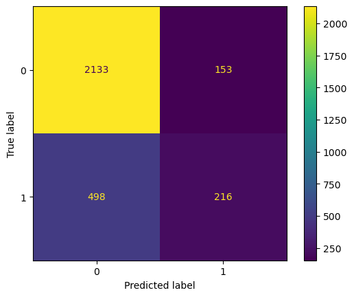

```python
cm_lr = confusion_matrix(y_test, pred_lr)
disp = ConfusionMatrixDisplay(cm_lr)
disp.plot()
```

### 5.2. Train a Random Forest Classifier model and apply the 5-Fold CV and plot the classification report.

```python
rfc = RandomForestClassifier(n_estimators=40)
score_rfc=cross_val_score(rfc,X_train, y_train, cv=5)
print(score_rfc)
print("Avg :",np.average(score_rfc))
```

```
[0.98140552 0.98085863 0.97812415 0.98249932 0.97948578]
Avg : 0.9804746779205253
```

```
              precision    recall  f1-score   support

           0       0.97      1.00      0.98      2286
           1       0.98      0.90      0.94       714

    accuracy                           0.97      3000
   macro avg       0.98      0.95      0.96      3000
weighted avg       0.97      0.97      0.97      3000
```

```
<sklearn.metrics._plot.confusion_matrix.ConfusionMatrixDisplay at 0x293341d2400>
```

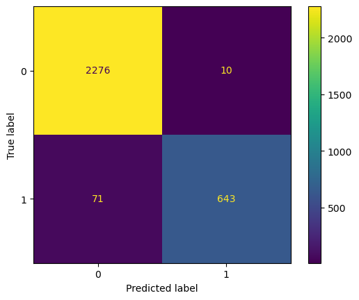

```python
pred_rfc = cross_val_predict(rfc, X_test, y_test, cv=5)
print(classification_report(y_test,pred_rfc))
cm_rfc = confusion_matrix(y_test, pred_rfc)
disp = ConfusionMatrixDisplay(cm_rfc)
disp.plot()
```

### 5.3. Train a Gradient Boosting Classifier model and apply the 5-Fold CV and plot the classification report.

```python
gbc = GradientBoostingClassifier(n_estimators=100, learning_rate=1.0,max_depth=1, random_state=0)
score_gbc=cross_val_score(gbc,X_train, y_train, cv=5)
print(score_gbc)
print("Avg :",np.average(score_gbc))
```

```
[0.95023243 0.94339623 0.9472245  0.94749795 0.95350109]
Avg : 0.9483704403114078
```

```
              precision    recall  f1-score   support

           0       0.97      0.98      0.97      2286
           1       0.92      0.91      0.91       714

    accuracy                           0.96      3000
   macro avg       0.95      0.94      0.94      3000
weighted avg       0.96      0.96      0.96      3000
```

```
<sklearn.metrics._plot.confusion_matrix.ConfusionMatrixDisplay at 0x293343ab100>
```

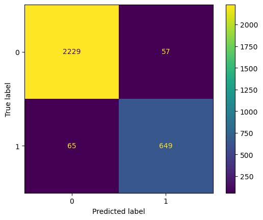

```python
pred_gbc = cross_val_predict(gbc, X_test, y_test, cv=5)
print(classification_report(y_test,pred_gbc))
cm_gbc = confusion_matrix(y_test, pred_gbc)
disp = ConfusionMatrixDisplay(cm_gbc)
disp.plot()
```

## 6. Identify the best model and justify the evaluation metrics used.

### 6.1. Find the ROC/AUC for each model and plot the ROC curve.

### 6.2. Find the confusion matrix for each of the models.

```
AUC: 0.798
```

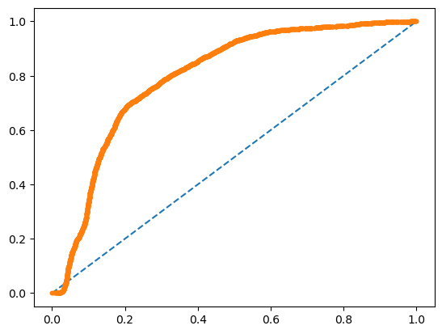

```python
#Preparing ROC Curve (Receiver Operating Characteristics Curve)
from sklearn.metrics import roc_curve
from sklearn.metrics import roc_auc_score

# Logestic Regression
# predict probabilities
probs_lr = cross_val_predict(lr, X, y, cv=5, method='predict_proba')
# keep probabilities for the positive outcome only
probs_lr = probs_lr[:, 1]
# calculate AUC
auc = roc_auc_score(y, probs_lr)
print('AUC: %.3f' % auc)
# calculate roc curve
fpr, tpr, thresholds = roc_curve(y, probs_lr)
# plot no skill
plt.plot([0, 1], [0, 1], linestyle='--')
# plot the roc curve for the model
plt.plot(fpr, tpr, marker='.')
```

```
AUC: 0.992
```

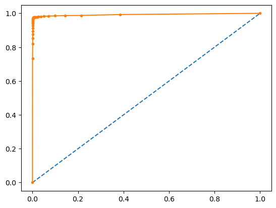

```python
# Random Forest Classifier
# predict probabilities
probs_rfc = cross_val_predict(rfc, X, y, cv=5, method='predict_proba')
# keep probabilities for the positive outcome only
probs_rfc = probs_rfc[:, 1]
# calculate AUC
auc = roc_auc_score(y, probs_rfc)
print('AUC: %.3f' % auc)
# calculate roc curve
fpr, tpr, thresholds = roc_curve(y, probs_rfc)
# plot no skill
plt.plot([0, 1], [0, 1], linestyle='--')
# plot the roc curve for the model
plt.plot(fpr, tpr, marker='.')
```

```
AUC: 0.979
```

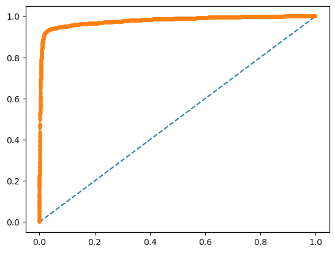

```python
# Gradient Boosting Classifier
# predict probabilities
probs_gbc = cross_val_predict(gbc, X, y, cv=5, method='predict_proba')
# keep probabilities for the positive outcome only
probs_gbc = probs_gbc[:, 1]
# calculate AUC
auc = roc_auc_score(y, probs_gbc)
print('AUC: %.3f' % auc)
# calculate roc curve
fpr, tpr, thresholds = roc_curve(y, probs_gbc)
# plot no skill
plt.plot([0, 1], [0, 1], linestyle='--')
# plot the roc curve for the model
plt.plot(fpr, tpr, marker='.')
```

## 7. Suggest various retention strategies for targeted employees.

### 7.1. Using the best model, predict the probability of employee turnover in the test data.

```python
pred_rfc
```

```
array([1, 1, 0, ..., 0, 0, 1], dtype=int64)
```

```python
test_predictions = pd.DataFrame(data=pred_rfc)
test_predictions
```

|  | 0 |
| --- | --- |
| 0 | 1 |
| 1 | 1 |
| 2 | 0 |
| 3 | 0 |
| 4 | 0 |
| ... | ... |
| 2995 | 0 |
| 2996 | 1 |
| 2997 | 0 |
| 2998 | 0 |
| 2999 | 1 |

3000 rows × 1 columns

```python
test_predictions.rename(columns={0:'predictions'},inplace=True)
test_predictions
```

|  | predictions |
| --- | --- |
| 0 | 1 |
| 1 | 1 |
| 2 | 0 |
| 3 | 0 |
| 4 | 0 |
| ... | ... |
| 2995 | 0 |
| 2996 | 1 |
| 2997 | 0 |
| 2998 | 0 |
| 2999 | 1 |

3000 rows × 1 columns

```python
prob = cross_val_predict(rfc, X_test, y_test, cv=5, method='predict_proba')
# keep probabilities for the positive outcome only
prob = prob[:, 1]
prob
```

```
array([0.975, 1.   , 0.   , ..., 0.075, 0.125, 0.975])
```

```python
probability = pd.DataFrame(data=prob)
probability
```

|  | 0 |
| --- | --- |
| 0 | 0.975 |
| 1 | 1.000 |
| 2 | 0.000 |
| 3 | 0.000 |
| 4 | 0.000 |
| ... | ... |
| 2995 | 0.250 |
| 2996 | 0.975 |
| 2997 | 0.075 |
| 2998 | 0.125 |
| 2999 | 0.975 |

3000 rows × 1 columns

```python
probability.rename(columns={0:'probability'},inplace=True)
probability
```

|  | probability |
| --- | --- |
| 0 | 0.975 |
| 1 | 1.000 |
| 2 | 0.000 |
| 3 | 0.000 |
| 4 | 0.000 |
| ... | ... |
| 2995 | 0.250 |
| 2996 | 0.975 |
| 2997 | 0.075 |
| 2998 | 0.125 |
| 2999 | 0.975 |

3000 rows × 1 columns

```python
len(probability)
```

```
3000
```

### 7.2. Based on the below probability score range, categorize the employees into four zones and suggest your thoughts on the retention strategies for each zone.

- Safe Zone (Green) (Score < 20%)
- Low Risk Zone (Yellow) (20% < Score < 60%)
- Medium Risk Zone (Orange) (60% < Score < 90%)
- High Risk Zone (Red) (Score > 90%).

```python
# create a list of our conditions
conditions = [
    (probability['probability'] <= 0.2),
    (probability['probability'] > 0.2) & (probability['probability'] <= 0.6),
    (probability['probability'] > 0.6) & (probability['probability'] <= 0.9),
    (probability['probability'] > 0.9)
    ]

# create a list of the values we want to assign for each condition
values = ['Safe Zone (Green)', 'Low Risk Zone (Yellow)', 'Medium Risk Zone (Orange)', 'High Risk Zone (Red)']

# create a new column and use np.select to assign values to it using our lists as arguments
probability['zone'] = np.select(conditions, values)

# display updated DataFrame
probability.head()
```

|  | probability | zone |
| --- | --- | --- |
| 0 | 0.975 | High Risk Zone (Red) |
| 1 | 1.000 | High Risk Zone (Red) |
| 2 | 0.000 | Safe Zone (Green) |
| 3 | 0.000 | Safe Zone (Green) |
| 4 | 0.000 | Safe Zone (Green) |

```python
print(X_test.shape)
print(test_predictions.shape)
print(probability.shape)
```

```
(3000, 18)
(3000, 1)
(3000, 2)
```

```python
X_test = X_test.reset_index()
```

```python
new_test_df = pd.concat([X_test,test_predictions,probability], axis=1)
new_test_df.head()
```

|  | index | satisfaction_level | last_evaluation | number_project | average_montly_hours | time_spend_company | Work_accident | promotion_last_5years | department_RandD | department_accounting | ... | department_marketing | department_product_mng | department_sales | department_support | department_technical | salary_low | salary_medium | predictions | probability | zone |
| --- | --- | --- | --- | --- | --- | --- | --- | --- | --- | --- | --- | --- | --- | --- | --- | --- | --- | --- | --- | --- | --- |
| 0 | 439 | 0.41 | 0.52 | 2 | 136 | 3 | 0 | 0 | 0 | 0 | ... | 0 | 0 | 0 | 0 | 1 | 1 | 0 | 1 | 0.975 | High Risk Zone (Red) |
| 1 | 649 | 0.46 | 0.50 | 2 | 156 | 3 | 0 | 0 | 0 | 0 | ... | 0 | 0 | 0 | 0 | 1 | 0 | 1 | 1 | 1.000 | High Risk Zone (Red) |
| 2 | 8478 | 0.58 | 0.63 | 5 | 191 | 3 | 1 | 0 | 0 | 0 | ... | 0 | 0 | 0 | 0 | 1 | 0 | 0 | 0 | 0.000 | Safe Zone (Green) |
| 3 | 13225 | 0.52 | 0.89 | 3 | 188 | 6 | 0 | 0 | 0 | 0 | ... | 1 | 0 | 0 | 0 | 0 | 0 | 1 | 0 | 0.000 | Safe Zone (Green) |
| 4 | 7962 | 0.74 | 0.54 | 4 | 167 | 2 | 0 | 0 | 0 | 0 | ... | 0 | 0 | 1 | 0 | 0 | 0 | 1 | 0 | 0.000 | Safe Zone (Green) |

5 rows × 22 columns

```python
new_test_df['zone'].value_counts()
```

```
Safe Zone (Green)            2254
High Risk Zone (Red)          544
Medium Risk Zone (Orange)     103
Low Risk Zone (Yellow)         99
Name: zone, dtype: int64
```

```python
new_test_df['zone'].value_counts()/len(new_test_df)
```

```
Safe Zone (Green)            0.751333
High Risk Zone (Red)         0.181333
Medium Risk Zone (Orange)    0.034333
Low Risk Zone (Yellow)       0.033000
Name: zone, dtype: float64
```

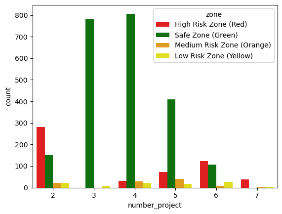

```python
colors = {'High Risk Zone (Red)':'red', 'Safe Zone (Green)':'green', 'Medium Risk Zone (Orange)':'orange', 'Low Risk Zone (Yellow)':'yellow'}
sns.countplot(data=new_test_df, x='number_project', hue='zone', palette= colors)
```

### Overview based on 'number_project' :

- From above plot, we can clearly say that employees who were involved in less 2 or less projects are most likely to leave the company.
- Also, enployees who were part of 6 or more projects were also more prone to leave the company. ### Solution :
- If companies decide the number of projects an employee can be part of it may help in retaining the employee. As we can clearly see less projects are not favourable to our cause niether is more projects.

```python
new_test_df['promotion_last_5years'].value_counts()
```

```
0    2929
1      71
Name: promotion_last_5years, dtype: int64
```

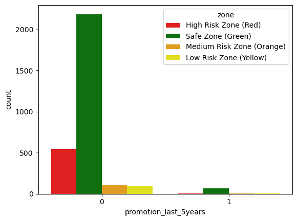

```python
sns.countplot(data=new_test_df, x='promotion_last_5years', hue='zone', palette= colors)
```

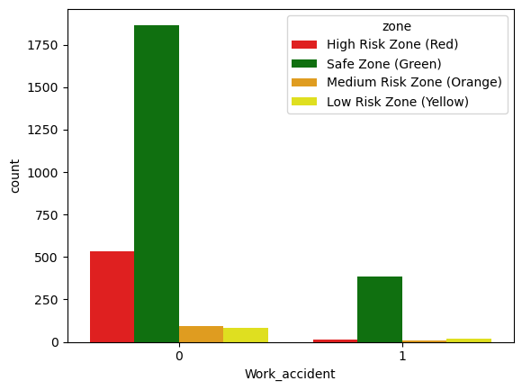

```python
sns.countplot(data=new_test_df, x='Work_accident', hue='zone', palette= colors)
```

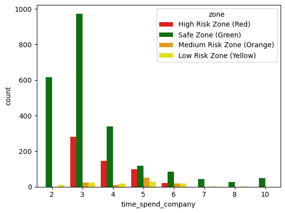

```python
sns.countplot(data=new_test_df, x='time_spend_company', hue='zone', palette= colors)
```

### Overview based on 'time_spend_company' :

- From above plot, we can clearly say that employees with experience between 3 to 5 yrs are likely to leave. ### Solution :
- This can be because after 3 yrs employees tend to look for more chalenging or leadership position.
- This can be handled by communicating with these employees and provide them better opportunity within the company according to their preference.

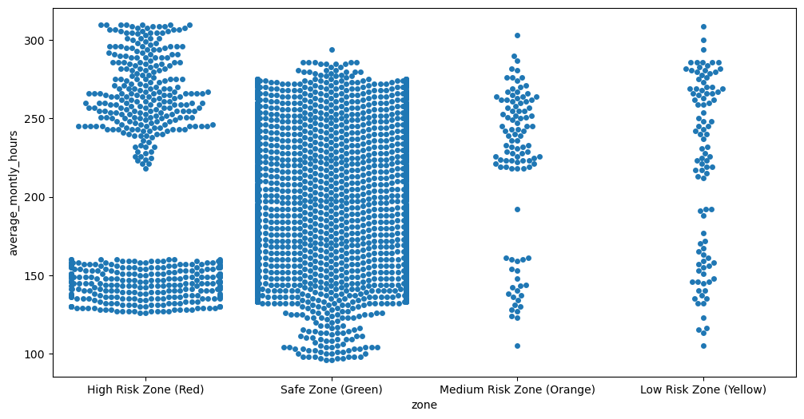

```python
# average_montly_hours
plt.figure(figsize=(12,6))
sns.swarmplot(data=new_test_df, x='zone', y='average_montly_hours')
```

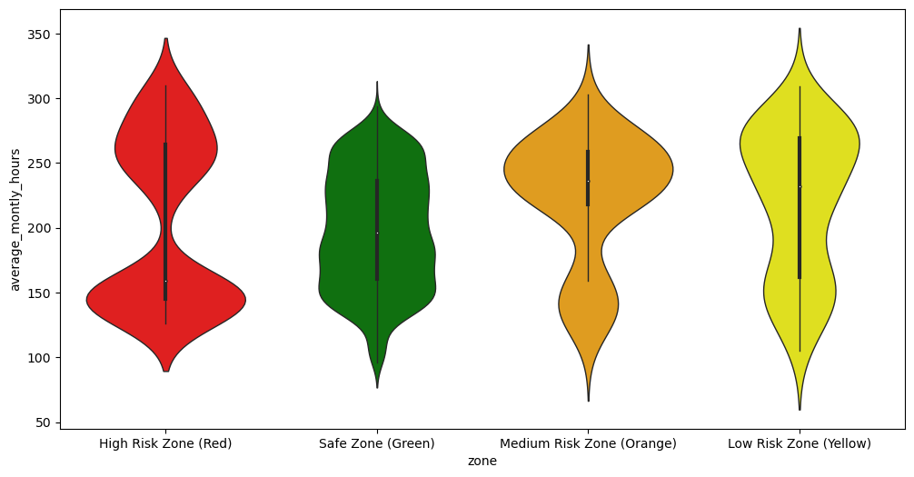

```python
plt.figure(figsize=(12,6))
sns.violinplot(x="zone",y="average_montly_hours",data=new_test_df, inner="box", palette=colors, cut=2, linewidth=1)
```

```python
new_test_df.columns
```

```
Index(['index', 'satisfaction_level', 'last_evaluation', 'number_project',
       'average_montly_hours', 'time_spend_company', 'Work_accident',
       'promotion_last_5years', 'department_RandD', 'department_accounting',
       'department_hr', 'department_management', 'department_marketing',
       'department_product_mng', 'department_sales', 'department_support',
       'department_technical', 'salary_low', 'salary_medium', 'predictions',
       'probability', 'zone'],
      dtype='object')
```

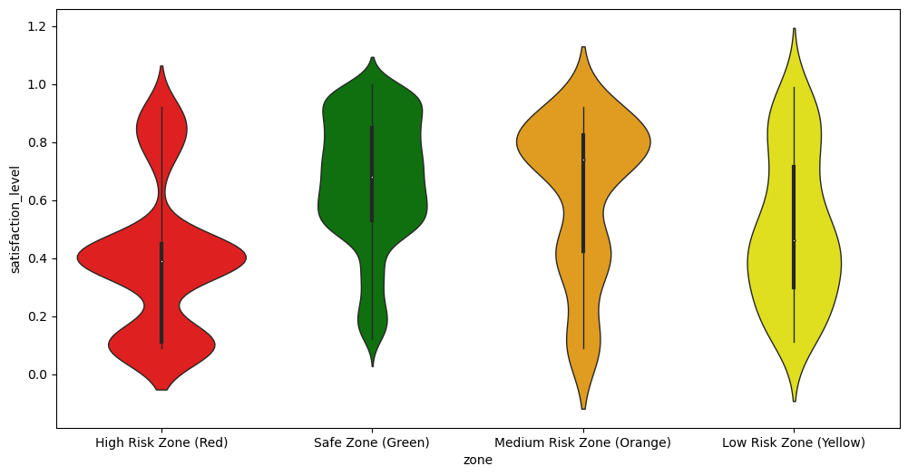

```python
plt.figure(figsize=(12,6))
sns.violinplot(x="zone",y="satisfaction_level",data=new_test_df, inner="box", palette=colors, cut=2, linewidth=1)
```

### Overview based on 'satisfaction_level' :

- From above plot, we can clearly say that employees with satisfaction level less than 0.4 were most likely to leave the company.
- Also, employees with satisfaction level of 0.6 were happy at the company and will not quit.
- But also, employees with satisfaction level of 0.8 and higher had some chance of quiting. ### Solution :
- Every company takes feed back from the employees on monthly basis about their experience in the company.
- Companies can simply study these trends throughly and address the problems faced by employees to make more work friendly environment for their employees.

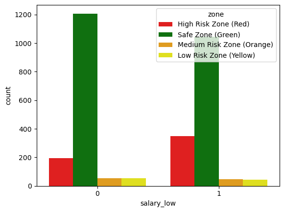

```python
sns.countplot(data=new_test_df, x='salary_low', hue='zone', palette= colors)
```

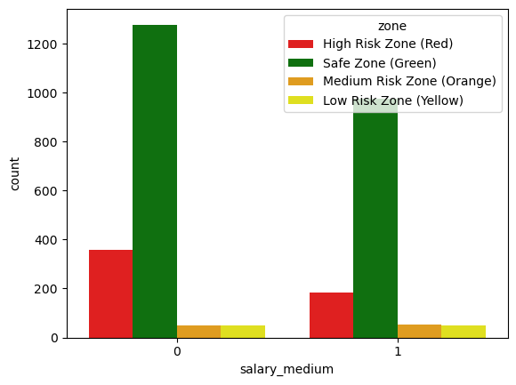

```python
sns.countplot(data=new_test_df, x='salary_medium', hue='zone', palette= colors)
```

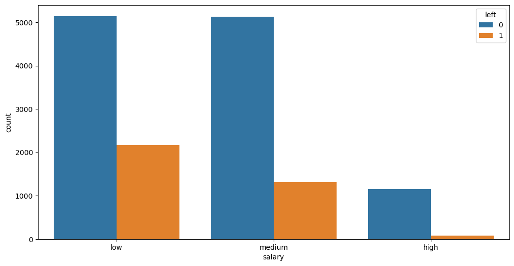

```python
plt.figure(figsize=(12,6))
sns.countplot(data=df, x='salary', hue='left')
```

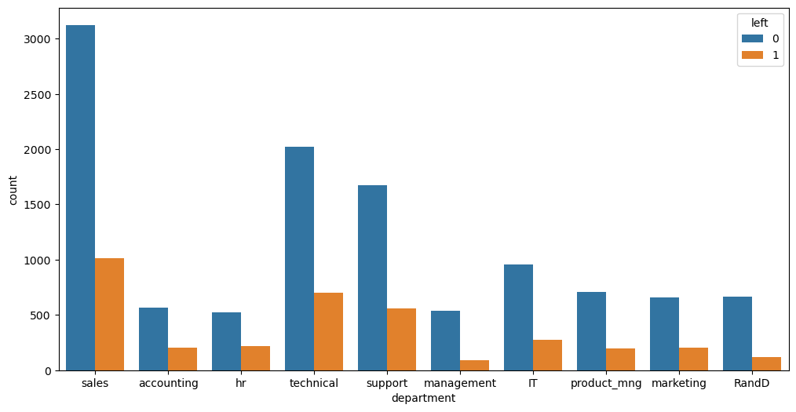

```python
plt.figure(figsize=(12,6))
sns.countplot(data=df, x='department', hue='left')
```

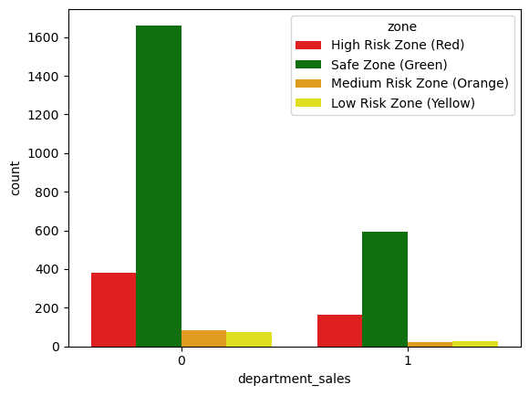

```python
sns.countplot(data=new_test_df, x='department_sales', hue='zone', palette= colors)
```